# Predicción Ventas Apple

Alvaro Rodríguez

22 Noviembre 2018

[figure not shown]

# 1 Resumen Ejecutivo

Se pretende realizar previsiones sobre series temporales de datos.Para ello asumimos dos enfoques distintos, Modelos de alisado exponencial y modelos ARIMA.

Aplicamos ambos modelos tanto a las ventas totales de Apple, Inc. como a cada una de las líneas de negocio que la compañía mantiene activa.

Se ha testeado la capacidad predictiva sobre datos muestrales, extrayendo los últimos 8 períodos trimestrales para poder comparar nuestras previsiones con los resultados reales.

Los resultados han sido más consistentes con respecto a la cartera total que con respecto a las líneas de negocio.

# 2 Introducción

Nuestro objetivo será predecir tanto las ventas totales de la compañía Apple, Inc. (Apple en adelante), como las ventas de una de las líneas de negocio operativas durante este periodo (iPhone, iPad, iPod, Apple dejó de comercializar iPods en 2015).

Vamos a llevar a cabo las predicciones desde dos perspectivas:

- Modelización ETS
- Modelización ARIMA

# 3 Datos

Se dispone de un dataset de ventas de Apple, que registra el nivel de ventas por cada línea de negocio (iPhone, iPad, iPod y Mac) de forma trimestral, desde el último trimestre de 1998 hasta el primer trimestre de 2016.

Se observa, si atendemos a los valores vacíos como la prímera línea de negocio de la compañía es “Mac”, Ipod fue el segundo en aparecer, pero fue retirado poco antes del final de nuestra muestra. iPhone y Ipad fueron lanzados a mediados de nuestra muestra.

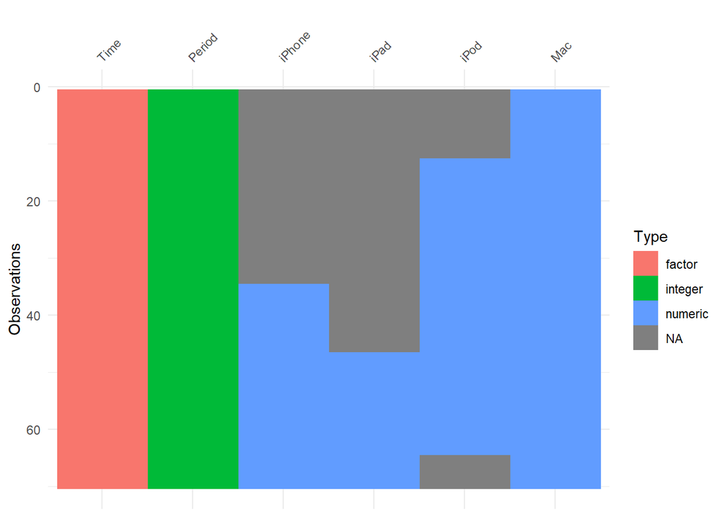

Adecuamos el dataset de ventas de Apple, siguiendo estos pasos:

- **Variable Period**: Eliminamos esta variable que unicamente identifica el número de periodos.
- **Valores Vacíos**: Se susituyen todos los valores vacíos -presente en las variables “iPhone”, “iPad” e “iPod”- por ceros.
- **Time**: Adecuamos los datos de fecha disponibles inicalmente al formato (1998-12-31)
- **Variable Total**: Creamos una variable con el total de cada periodo.

# 4 Análisis exploratorio de datos

Una vez se ha adecuado el dataset, análizamos los datos que contiene para extraer las primeras conclusiones.

En primer lugar, representamos la muestra completa, representando las ventas trimestrales tanto de cada línea de negocio, como del total agregado de la compañía.

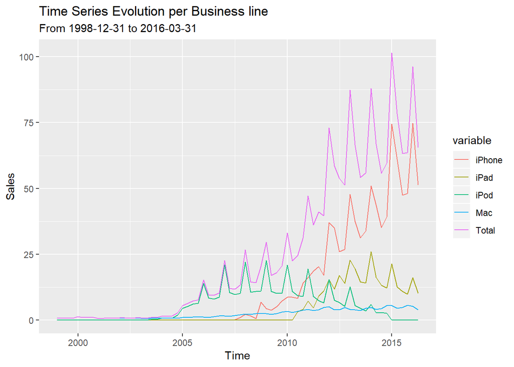

Se observa como tanto los valores agregados como los de iPhone y Mac, tienen una tendencia positiva. No es así con respecto a los valores de iPad, que también presenta una tendencia, pero en su caso negativa.

La series presentan picos estacionales, que deberemos analizar para poder interpretar que tipo de estacionalidad predomina.

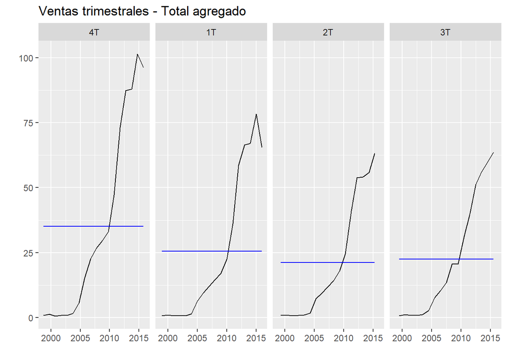

Examinos de la misma manera, la evolución por trimestres de cada una de las líneas de negocio actuales de la compañía.

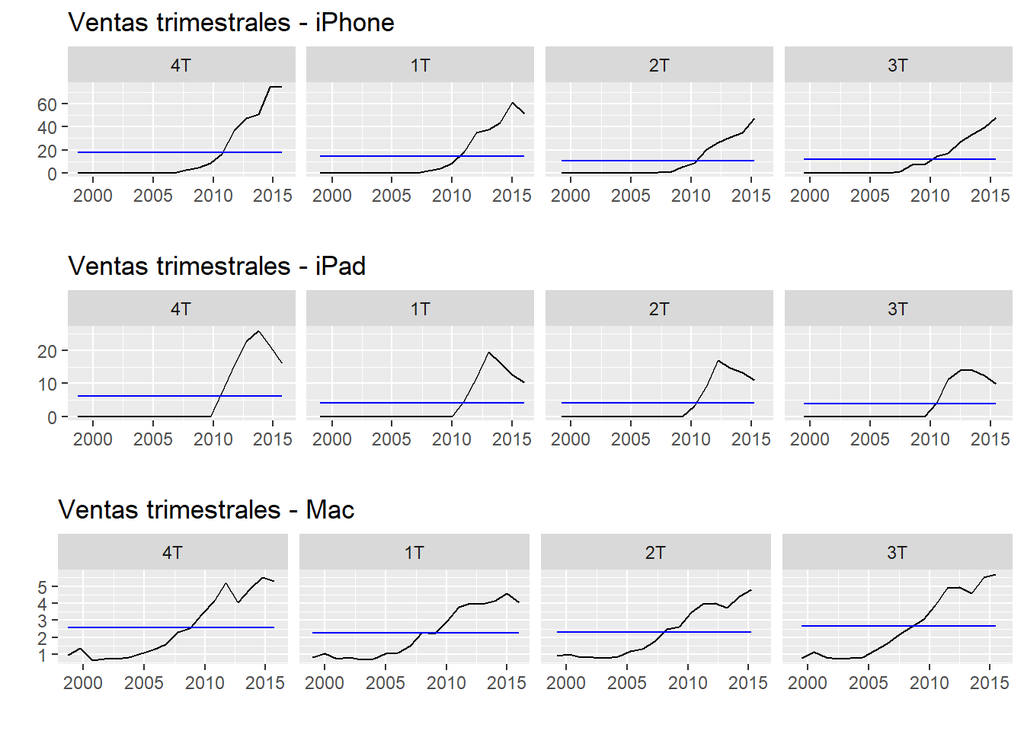

# 5 Modelización

Utilizaremos dos modelos distintos para predecir, modelos ETS (alisado exponencial) y modelos ARIMA (Modelos Autorregresivos Integrados de Medias Móviles). Si bien los modelos de suavizado exponencial lineal son todos casos especiales de los modelos ARIMA, los modelos de suavizado exponencial no lineal no tienen modelo ARIMA equivalente. Por otro lado, también hay muchos modelos ARIMA que no tienen equivalente en suavizado exponencial. En particular, todos los modelos ETS no son estacionarios, mientras que algunos modelos ARIMA son estacionarios.

## 5.1 Modelización ETS

Emplean el alisado exponencial para predecir nuevos valores de la serie, de manera que las observaciones más recientes tienen más peso en la predicción que las más alejadas.

Estos modelos van desde el alisado exponencial simple, pasando por el alisado de tendencia de Holts que incluye una parámetro de tendencia (también un parámetro de alisado de tendencia) y que puede pueden ser aditivos o multiplicativos dependiendo de la relación entre el nivel y la tendencia. La amortiguación de la tendencia se obtiene con la inclusión de un nuevo parámetro $φ$.

Por último, los modelos Holt-Winters incluyen además de los compenentes de error y tendencia, un componente estacional. Así, s es el componente estacional y m el periodo de la estacionalidad (m=4 para trimestral). De nuevo el modelo puede ser aditivo (el componente estacional no cambia cuando cambia la tendencia de la serie) o multiplicativo (el componente estacional cambia cuando cambia la tendencia de la serie).

### 5.1.1 Agregado

Dadas las características de nuestra muestra -habiendo testeado otros métodos- el modelo resultante sería ETS(M,A,M) -Alisado exponencial con error Multiplicativo, tendencia aditiva y componente estacional multiplicativo). **Probaremos a ajustar la previsión para el modelo con tendencia sin amortiguar y amortiguada (M,Ad,M)**.

Entrenamos uno y otro modelo con los datos de las muestra, omitiendo los ocho últimos trimestres (dos años). Representamos tanto la evolución real, como la evolución prevista conforme a ambos modelos.

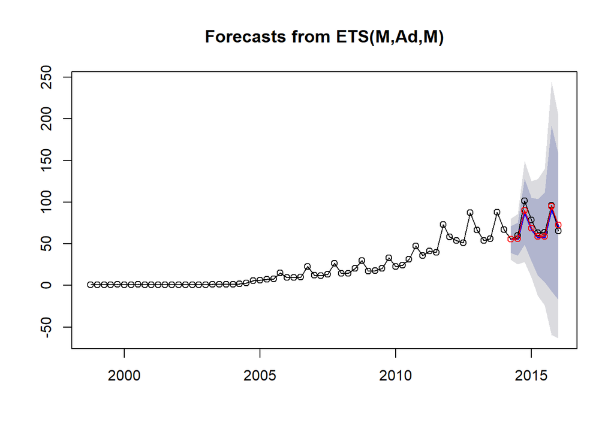

Vemos como ambos modelos consiguen predecir con consistencia los últimos 8 trimestres. Para elegir, de manera definitiva, cual de los dos modelos utilizaremos, atendemos al error de predección ($e_{t} = \bar{y_{t}} - y_{t}$). Se calcula el error absoluto por cada observación.

| Real | Forecast ETS Damped | Abs.Error.Damped | Forecast ETS | Abs.Error |
| --- | --- | --- | --- | --- |
| 55.818 | 55.39372 | 0.4242799 | 55.59739 | 0.2206065 |
| 59.749 | 55.57025 | 4.1787494 | 55.94421 | 3.8047924 |
| 101.406 | 88.53556 | 12.8704368 | 90.23263 | 11.1733653 |
| 78.356 | 67.36040 | 10.9956007 | 68.57115 | 9.7848469 |
| 63.261 | 57.78037 | 5.4806250 | 58.64218 | 4.6188213 |
| 63.640 | 57.95258 | 5.6874153 | 59.00009 | 4.6399070 |
| 96.210 | 92.31289 | 3.8971093 | 95.14890 | 1.0610964 |
| 65.480 | 70.22096 | 4.7409589 | 72.29776 | 6.8177609 |

El modelo sin amortiguar es el que tiene menor error medio abosulto (5,25) con respecto a la ventas reales que habíamos eliminado de nuestra muestra para testear el poder predictivo de los modelos.

### 5.1.2 Desagregado

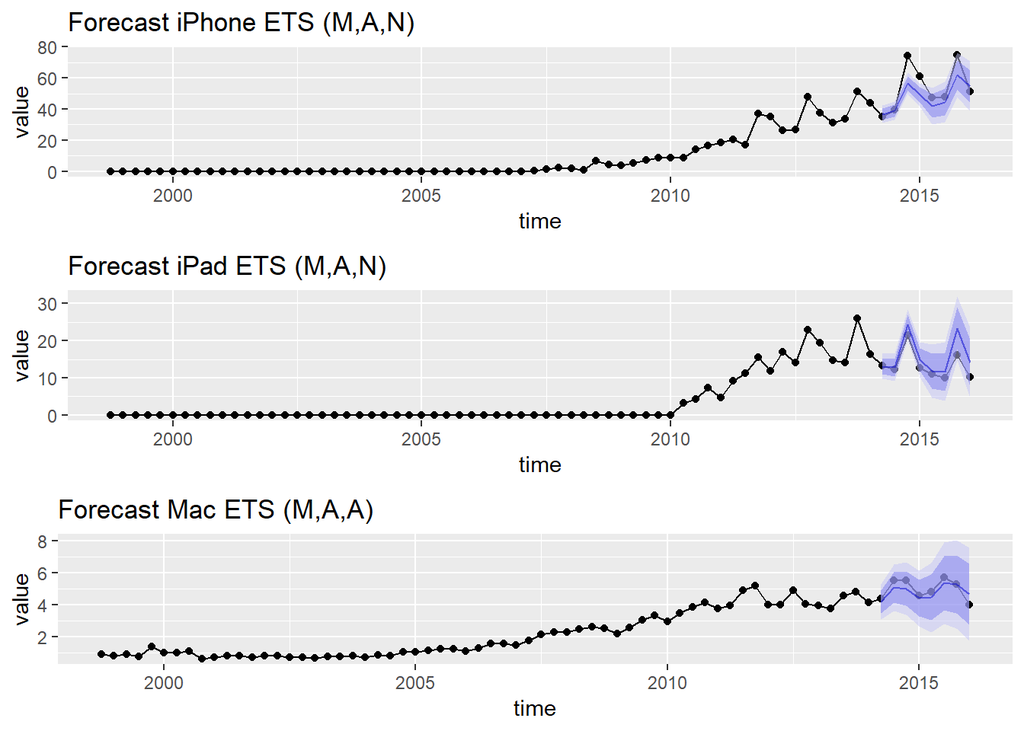

## 5.2 Modelización ARIMA

el modelo ARIMA utiliza variaciones y regresiones de datos estadísticos con el fin de encontrar patrones para una predicción hacia el futuro.

Estos modelos son, en teoría, la clase más general de modelos para pronosticar una serie de tiempo que puede ser “estacionaria”. Una serie temporal es estacionaria si su media y varianza son constantes a lo largo del tiempo. Es igualmente importante que sus autocorrelaciones (correlaciones con sus propias desviaciones previas de la media) permanecen constantes a lo largo del tiempo.

Así las cosas, una serie estacionaria no tiene tendencia, sus variaciones en torno a su media tienen una amplitud constante, y se ondula de manera consistente, es decir, sus patrones de tiempo aleatorios a corto plazo siempre se ven iguales en un sentido estadístico.

Un modelo ARIMA puede verse como un “filtro” que intenta separar la señal del ruido, y luego la señal se extrapola al futuro para obtener pronósticos.

### 5.2.1 Agregado

Resulta evidente, que la serie tal y como se ha dispuesto hasta ahora no cumple con estás carácterísticas de una serie estacionaria ya que anteriormente ya hemos identificado que la media no es constante y que existe una marcada estacionalidad.

Para ello, convertir la serie a rendimientos logarítmicos. Una vez llevado a cabo este procedimiento buscamos el modelo ARIMA cuyos residuos (errores) sean ruido blanco, esto es, errores con media cero constante, varianza constante y sin autocorrelación.

El modelo resultante es una ARIMA(1,0,0)(1,1,0)[4]. Los primeros tres parámetros se refieren a la parte regular, que se ajusta como un modelo autorregresivo de orden 1. La segunda parte corresponde a la parte estacional, 4 indica el número de periodos de la estacionalidad, es consistente con lo establecido en el modelo ETS.

Es momento de comprobar que los errores son ruido blanco.

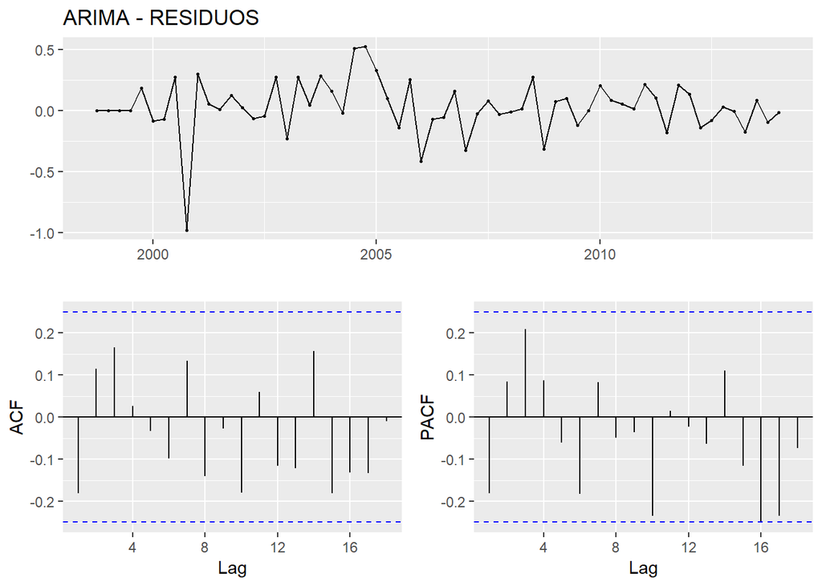

Efectivamente, los errores del modelo son ruido blanco y el componente estacional se ha reflejado adecuadamente en el modelo, cuyas autocorrelaciones están por debajo del intervalo de confianza de manera que no son significativas.

Igualmente, se realiza el **Test Box-Ljung**. Se pretende verificar si un grupo cualquiera de autocorrelaciones de una serie de tiempo son diferentes de cero. En lugar de probar la aleatoriedad en cada retardo distinto, esta prueba la aleatoriedad “en general” basado en un número de retardos.

Visualizamos el ajuste de las previsiones, sobre nuestra los últimos 8 periodos de la muestra.

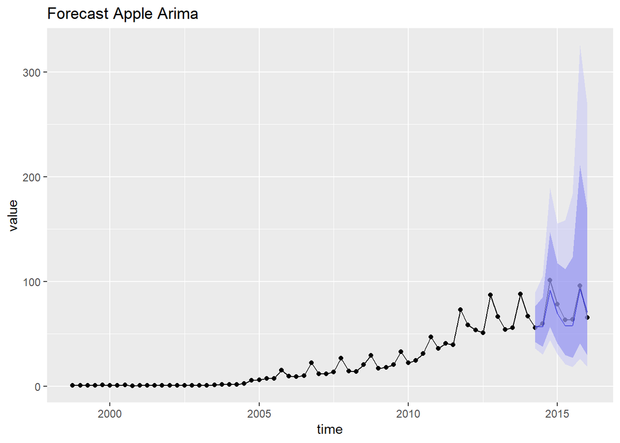

### 5.2.2 Desagregado

Realizamos el mismo procedimiento para cada una de las líneas de negocio de Apple, observamosque los residuos de los modelos ARIMA calculados, para iPhone y iPad no son ruido blanco.

En cualquier caso, visualizamos la representación de las respectivas predicciones con modelos ARIMA.

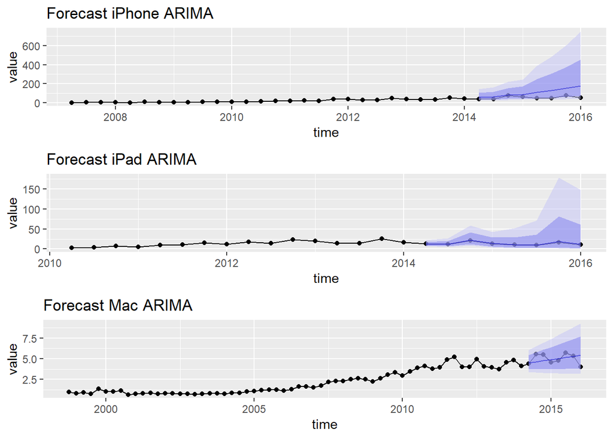

# 6 Conclusión

Hemos podido ajustar tanto un modelo ETS como un modelo ARIMA.

Los modelos se han testeado entrenando el modelo sin los dos últimos años y prediciendo los 8 últimos periodos trimestrales. Tales predicciones tanto con el modelo ETS como en el modelo ARIMA han ajustado de forma adecuada 8 periodos de ventas de Apple.

Las previsiones has sido más consistentes sobre el total agregado que sobre las líneas de negocio cuyo ajuste ha sido en general menos ajustada.